# Protocol for Implementing Distributed Cox Regression on CCASAnet

for Mexico (participating site)

Author

Kaixing Liu

Published

August 8, 2025

Modified

August 13, 2025

## 1 Preparation

### 1.1 Action 1

1. **Create/Choose a directory in your local machine** at your discretion.
   - For example, I created a local directory with absolute path, `"/Users/lkx220/Desktop/mexico"`.
2. **Download from the cloud** (e.g., OneDrive) the following items,
   - **R scripts**, `distributed-analysis-ccasanet.R` and `authentic-distributed-analysis.R`, to the local directory specified in **1.**, say `"/Users/lkx220/Desktop/mexico"`;
   - **site-specific individual-level data**: Mexico shall download `mexico_all_trt.rds` and `mexico_all_vl.rds` to the same local directory;
   - **global set-up file**: `setup.rds` to the same local directory;
   - **site-specific instruction**: Mexico should download `protocol-CCASAnet-Mexico.html` to anywhere in your local machine (this file is meant to guide you the procedures of implementation of this distributed analysis);

#### 1.1.1 Check

**Make sure** that R scripts, set-up file, and the data are in the same local directory, shown below.

**This local directory** (chosen at your discretion) would be the **working directory in R** **later**.

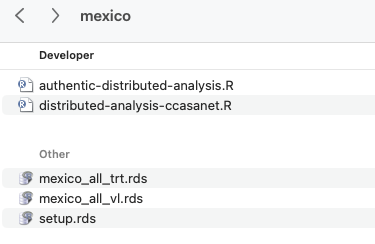

### 1.2 Action 2

1. Open RStudio or R and set working directory as the local directory you chosen in **Preparation**.

   You may as well run the command below in your R console.

   ```r
   # setwd("your-working-directory")
   setwd("/Users/lkx220/Desktop/mexico") # my example
   ```

2. Source the code and import data and set-up file.

   Please execute code below in console.

   ```r
   source("distributed-analysis-ccasanet.R")
   source("authentic-distributed-analysis.R")
   mexico.vl = readRDS("mexico_all_vl.rds")
   mexico.trt = readRDS("mexico_all_trt.rds")
   setup = readRDS("setup.rds")
   # prepare data for different scenarios
   # for Mexico
   ## you can just ignore warning messages
   mexico.vl.cc = mexico.vl %>% subset(!is.na(sex_mode) & !is.na(cd4_v_initial_sqrt) & !is.na(rna_v_initial_log))
   mexico.vl.mi = mice.local.merge(mice(mexico.vl %>% select(all_of(setup[["vl.imp.var"]])), m=setup[["no.of.imputation"]], method = "pmm",
                                    seed = setup[["seed"]], printFlag = FALSE), m=setup[["no.of.imputation"]])
   mexico.trt.cc = mexico.trt %>% subset(!is.na(sex_mode) & !is.na(cd4_v_initial_sqrt) & !is.na(rna_v_initial_log))
   mexico.trt.mi = mice.local.merge(mice(mexico.trt %>% select(all_of(setup[["trt.imp.var"]])), m=setup[["no.of.imputation"]], method = "pmm",
                                    seed = setup[["seed"]], printFlag = FALSE), m=setup[["no.of.imputation"]])
   ```

## 2 Implementation

### 2.1 Virologic Failure, Complete-Case Analysis

**Initialization**

**—Wait for Chile to upload `control.json` file to the cloud.—**

1. After downloading `control.json` along with the `"vl/complete-case"` directory in the cloud to local directory.

   **CHECK**

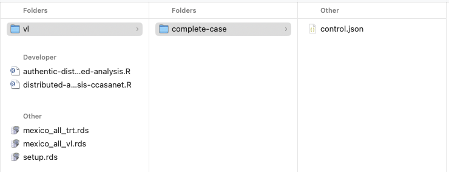

   and

   the “step” in `control.json` file in `"./vl/complete-case"` should be “initialize” (you can just open the `control.json` file or preview it if possible).

   Then run the code below.

   ```r
   set.seed(setup[["seed"]])
   pda.local(mexico.vl.cc, "mexico", getwd(), m = 1, complete = TRUE, outcome = "vl")
   ```

   **CHECK**

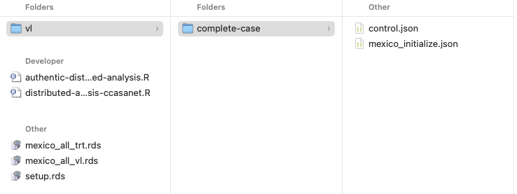

2. Mexico uploads this `mexico_initialize.json` to `"./vl/complete-case"` in the cloud.

**Derivation**

**—Wait for Chile to update `control.json` file in the cloud.—**

1. Mexico downloads `control.json` file again from `"./vl/complete-case"` in the cloud to local `"./vl/complete-case"`.

   **CHECK**

   The “step” in `control.json` file in `"./vl/complete-case"` should be “derive” now (you can just open the `control.json` file or preview it if possible).
2. Mexico runs command below.

   ```r
   set.seed(setup[["seed"]])
   pda.derive(mexico.vl.cc, "mexico", getwd(), m = 1, complete = TRUE, outcome = "vl")
   ```

   **CHECK**

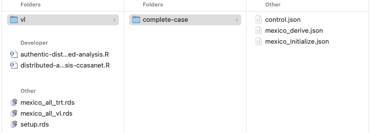

3. Mexico uploads `mexico_derive.json` in local `"./vl/complete-case"` to `"./vl/complete-case"` in the cloud.

**—You are Done for federated analysis in this scenario.—**

Now you probably get familiar with the procedure.

For virologic failure with multiple imputation later, the procedures are the same overall except that we will do this per imputed data set.

No worries. The command given below realize this in parallel and this means you still just need run it once.

**But you need do more when downloading and uploading files since we have multiple imputed data sets**.

### 2.2 Virologic Failure, with Multiple Imputation

**Initialization**

**—Wait for Chile to upload `control.json` file in OneDrive.—**

1. After downloading `control.json` along with the number-indexed directory in OneDrive to local directory,

   **CHECK**

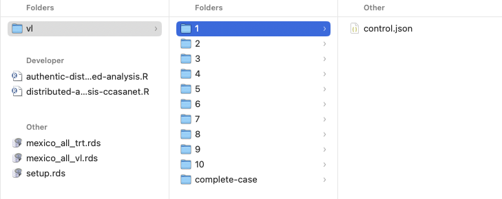

   and

   the “step” in `control.json` file in `"./vl/1"` should be “initialize” (you can just open the `control.json` file or preview it if possible).

   Then run the command below

   ```r
   set.seed(setup[["seed"]])
   pda.local(mexico.vl.mi, "mexico", getwd(), m = setup[["no.of.imputation"]], outcome="vl")
   ```

   **CHECK**

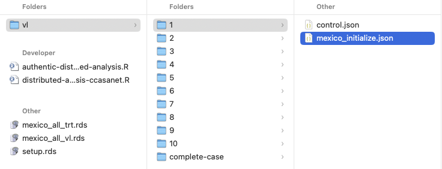

2. Mexico uploads `mexico_initialize.json` in each local number-indexed directory to corresponding number-indexed directory in the cloud.

**Derivation**

**—Wait for Chile to update `control.json` file.—**

1. Mexico downloads `control.json` file in each number-indexed directory from the cloud to corresponding local number-indexed directory.

   **CHECK**

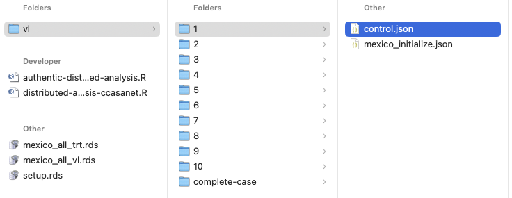

   and

   the “step” in `control.json` file in `"./vl/1"` should be “derive” (you can just open the `control.json` file or preview it if possible).
2. Mexico runs command below.

   ```r
   set.seed(setup[["seed"]])
   pda.derive(mexico.vl.mi, "mexico", getwd(), m = setup[["no.of.imputation"]], outcome = "vl")
   ```

   **CHECK** (`mexico_derive.json`)

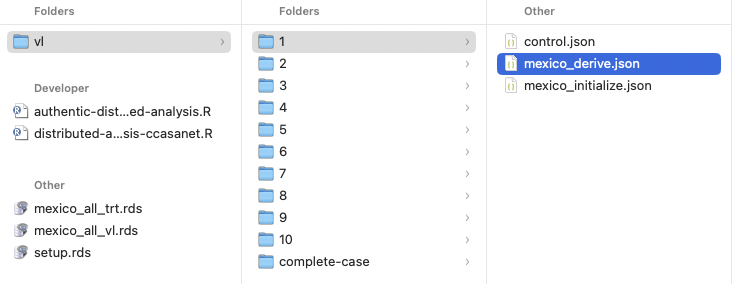

3. Mexico uploads `mexico_derive.json` in each number-indexed directory to corresponding number-indexed directory in the cloud.

**—You are Done for federated analysis in this scenario.—**

**Regarding Major Regimen Change, we just repeat the above procedures.**

### 2.3 Major Regimen Change, Complete-Case Analysis

**Initialization**

**—Wait for Chile to upload `control.json` file to the cloud.—**

1. After downloading `control.json` along with the `"trt/complete-case"` directory in the cloud to local directory.

   **CHECK** similarly

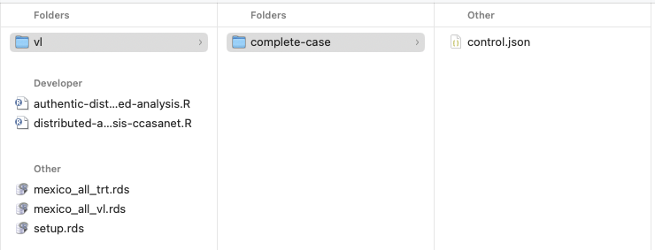

   and

   the “step” in `control.json` file in `"./trt/complete-case"` should be “initialize” (you can just open the `control.json` file or preview it if possible).

   Then run the code below.

   ```r
   set.seed(setup[["seed"]])
   pda.local(mexico.trt.cc, "mexico", getwd(), m = 1, complete = TRUE, outcome = "trt")
   ```

   **CHECK similarly**

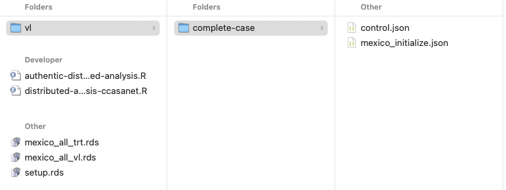

2. Mexico uploads this `mexico_initialize.json` to `"./trt/complete-case"` in the cloud.

**Derivation**

**—Wait for Chile to update `control.json` file in the cloud.—**

1. Mexico downloads `control.json` file again from `"./trt/complete-case"` in the cloud to local `"./trt/complete-case"`.

   **CHECK**

   The “step” in `control.json` file in `"./trt/complete-case"` should be “derive” now (you can just open the `control.json` file or preview it if possible).
2. Mexico runs command below.

   ```r
   set.seed(setup[["seed"]])
   pda.derive(mexico.trt.cc, "mexico", getwd(), m = 1, complete = TRUE, outcome = "trt")
   ```

   **CHECK similarly**

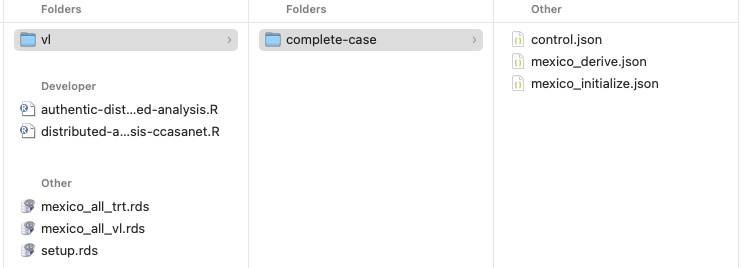

3. Mexico uploads `mexico_derive.json` in local `"./trt/complete-case"` to `"./trt/complete-case"` in the cloud.

**—You are Done for federated analysis in this scenario.—**

Now you probably get familiar with the procedure.

For major regimen change with multiple imputation later, the procedures are the same overall except that we will do this per imputed data set.

No worries. The command given below realize this in parallel and this means you still just need run it once.

**But you need do more when downloading and uploading files since we have multiple imputed data sets**.

### 2.4 Major Regimen Change, with Multiple Imputation

**Initialization**

**—Wait for Chile to upload `control.json` file in OneDrive.—**

1. After downloading `control.json` along with the number-indexed directory in OneDrive to local directory,

   **CHECK similarly**

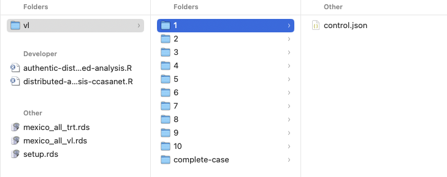

   and

   the “step” in `control.json` file in `"./trt/1"` should be “initialize” (you can just open the `control.json` file or preview it if possible).

   Then run the command below

   ```r
   set.seed(setup[["seed"]])
   pda.local(mexico.trt.mi, "mexico", getwd(), m = setup[["no.of.imputation"]], outcome="trt")
   ```

   **CHECK similarly**

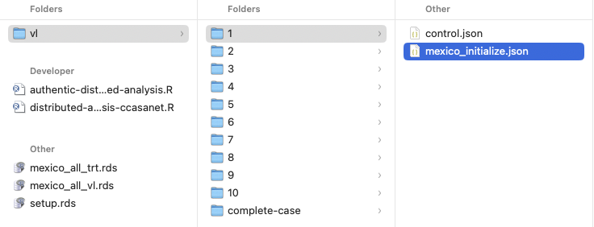

2. Mexico uploads `mexico_initialize.json` in each local number-indexed directory to corresponding number-indexed directory in the cloud.

**Derivation**

**—Wait for Chile to update `control.json` file.—**

1. Mexico downloads `control.json` file in each number-indexed directory from the cloud to corresponding local number-indexed directory.

   **CHECK similarly**

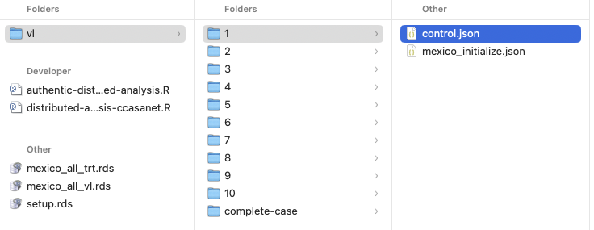

   and

   the “step” in `control.json` file in `"./trt/1"` should be “derive” (you can just open the `control.json` file or preview it if possible).
2. Mexico runs command below.

   ```r
   set.seed(setup[["seed"]])
   pda.derive(mexico.trt.mi, "mexico", getwd(), m = setup[["no.of.imputation"]], outcome = "trt")
   ```

   **CHECK similarly** (`mexico_derive.json`)

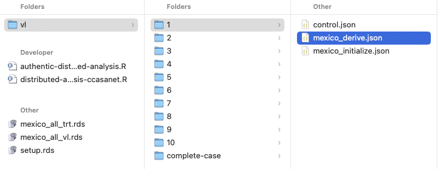

3. Mexico uploads `mexico_derive.json` in each number-indexed directory to corresponding number-indexed directory in the cloud.

**—You are Done for federated analysis in this scenario.—**